# Censored observations in mixed-model regression

28 March 2017

## Motivation

- CML clinical trial
- molecular measurement of remission level
- patients are followed-up
- bi-exponential form per patient assumed
- lower detection limit for individual measurements
- compare two treatments

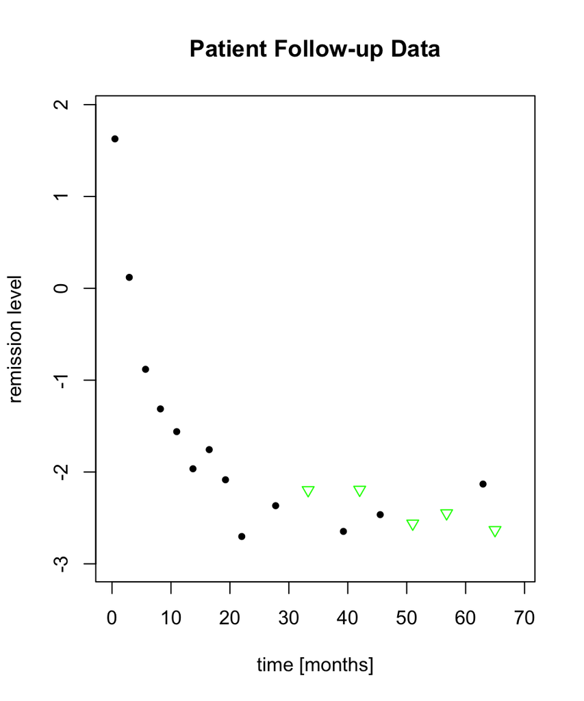

## Censoring

## Censoring

- A response \(X\) is known to have occurred only within certain interval
- Known from survival analysis
  - Response: survival time, i.e. time to death
  - Censoring: partially observed survival time, i.e. last seen alive
- Right censoring: \(X ∈ [c_r, ∞)\)
- Left censoring: \(X ∈ (-∞, c_l]\)
- Types of censoring
  - fixed right censoring time, e.g. study end ("Type I censoring")
  - random (left or right) censoring

## Random left censoring

- \(X\) true response variable
- \(C_l\) censoring variable
- observe **(T, δ)** with
  - \(T=\max(X, C_l);\,\) δ ∈ {0,1} status
  - δ=0 censoring: \[T = C_l \text{ and } X < C_l\]
  - δ=1 event: \[T = X \text{ and } X ≥ C_l\]

| Function | Event X | Censoring C<sub>l</sub> |
| --- | --- | --- |
| Density | f | g |
| Cum Distrib | F | G |
| Survival | S = 1-F | H = 1-G |

## Likelihood Model

- Assume distribution for \(X\) with density f<sub>θ</sub> with parameter θ
- Given a random sample x=(x<sub>1</sub>, .., x<sub>n</sub>)
- Generally: \[L(θ\,|\, x) \propto \prod_{i=1}^n f_θ(x_i)\]

## Density for (T, δ)

- Assume independence of X and C \[ \begin{aligned} f(t, δ = 1) &= f(t) \cdot (1-H(t))\\[1.5ex] f(t, δ = 0) &= g(t) \cdot (1-S(t))\\ \end{aligned} \]
- Together \[ \begin{aligned} f(t, δ) &= (g(t) \cdot (1-S(t)))^{1-δ} \cdot ( f(t) \cdot (1-H(t)) )^δ\\ &= \underbrace{f(t)^δ (1-S(t))^{1-δ}}_{\text{response}} \cdot \underbrace{g(t)^{1-δ} (1-H(t))^δ}_{\text{censoring}} \end{aligned} \]

## Likelihood Model for Left-Censoring

- Likelihood \[ \begin{aligned} L &= \prod_{i=1}^n f(t_i, δ_i)\\ &= \prod_{i=1}^n f(t_i)^{δ_i} (1-S(t_i))^{1-δ_i} \cdot g(t_i)^{1-δ_i} (1-H(t_i))^{δ_i} \end{aligned} \]
- If censoring independent of the response event: \[ L \propto \prod_{i=1}^n f(t_i)^{δ_i} (1-S(t_i))^{1-δ_i} = \prod_{i∈D} f(x_i) \cdot \prod_{i∈L} [1-S(x_i)] \]

## Likelihood contributions

- For independent censoring:

| Observed response | Abbrev | Contribution |
| --- | --- | --- |
| exact | D | f(x) |
| right-censored | R | S(x) |
| left-censored | L | 1-S(x) |
| interval-censored | I | S(L) - S(R) |

\[ L \propto \prod_{i∈D} f(x_i) \cdot \prod_{i∈R} S(x_i) \cdot \prod_{i∈L} [1-S(x_i)] \cdot \prod_{i∈I} [ S(L_i) - S(R_i)] \]

## Example

- Exponentially distributed response
- Random right censoring, independent of the response
- Sample {(t<sub>1</sub>, δ<sub>1</sub>), …, (t<sub>n</sub>, δ<sub>n</sub>)} with \(r\) observed events (|D|=r)
- Density \(f(x) = λ \exp(-λ x)\) and survival \(S(x) = \exp(-λ x)\) with λ > 0
- Likelihood: \(L \propto \prod_{i∈D} f(x_i) \cdot \prod_{i∈R} S(x_i)\)
- \(L(λ) = λ^r \cdot \exp(-λ \sum_i t_i)\)
- \(\hat λ = \frac{r}{\sum_i t_i}\)

## Example

- Exponential distribution with parameter λ > 0
- Random left censoring \[ \begin{aligned} L(λ) &= \prod_{i∈D} f(x_i) \cdot \prod_{k∈L} [1-S(x_k)] \\ &= λ^r \cdot \exp(-λ \sum_{i∈D} t_i) \cdot \prod_{k∈L} (1-\exp(-λ t_k)) \end{aligned} \]
- More complex form than with right censoring

## Example: own ML-implementation

```r
# neg. log-likelihood
negLogLik_expLCens <- function(data){

  nbrEvents <- sum(data$status)
  eventIdx <- data$status == 1L

  function(l)
    - nbrEvents * log(l) + l * sum(data$T[eventIdx]) -
    sum(log(1-exp(-l * data$T[!eventIdx])))
}

## find MLE
optimize(negLogLik(data), interval = c(0, 10))
```

## Implementation in R's `survival` package

- `survival::survreg` function for ML-fitting with censored observations
- Left-censoring

```r
survreg(Surv(T, status, type = "left") ~ 1, dist = "exp", data)
```

- Right-censoring

```r
survreg(Surv(T, status, type = "right") ~ 1, dist = "exp", data)
```

## Example: Tobit model

- Linear model with left-censored response ('latent' response) (Tobin, Econometrica, 1958) \[ \begin{aligned} y^* &= X β + ε \qquad \text{ with } ε\sim {\mathcal{N}(0, σ^2\cdot I_n)} \\[1ex] y_i &= \Bigl\{ \begin{matrix} 0 & \text{ if } y_i^* ≤ 0 \\ y_i^* & \text{ if } y_i^* > 0 \end{matrix} \end{aligned} \]
- Normal density \(ϕ_{μ, σ^2}\) and distribution function \(F=Φ_{μ, σ^2}\)
- Likelihood \[L = \prod_{i∈D} ϕ_{x_i{^\intercal}β,σ^2}(y_i) \prod_{j∈L} Φ_{x_i{^\intercal}β,σ^2}(y_i)\]

## Example: implementation in `lme4cens`

- re-use `Surv`-object to model censoring in response

```r
lmcens(Surv(affairs, event, type = "left") ~ age + yearsmarried + occupation + rating,
       data = Affairs)
```

```
##
## Call:
## lmcens(formula = Surv(affairs, event, type = "left") ~ age +
##     yearsmarried + occupation + rating, data = Affairs)
##
## Coefficients:
##  (Intercept)           age  yearsmarried    occupation        rating
##       0.4889       -0.1099        0.4231        0.4820       -2.1975
##       lSigma
##       2.1553
```

## Mixed models

## Example: `sleepstudy`

- Reaction time after continued sleep deprivation
- Subset of four subjects

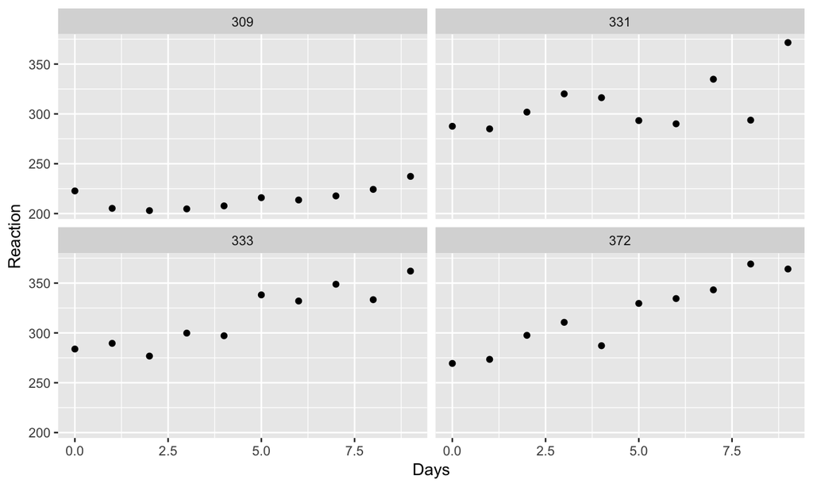

## The Linear Mixed Model

- Described by 2 vector-valued random variables
  - the response vector \(Y\) *and*
  - the vector of random effects \(B\)
- conditional distribution of \(Y\) given \(B=b\) is modelled as \[ Y_{\;|\; B = b} \sim {\mathcal{N}(X\beta + Zb, \, \sigma^2 I_n)} \]
- \(β∈ℝ^p\) fixed effects
- \(b∈ℝ^q\) random effects
- Conditionally on \(B=b\), a simple diagonal covariance structure for \(Y\)
- \(Y\) is multivariate normal with complex covariance structure

## Random effects

- \(B \sim {\mathcal{N}(0, Σ_θ)}\) where \(Σ_θ\) is a \(q\times q\)-covariance matrix.
- \(Σ_θ = σ^2 Λ_θ Λ_θ^T\) Cholesky-decomposition
  - variance-component parameter θ *and*
  - **relative covariance factor** \(Λ_θ ∈ ℝ^{q\times q}\)
- Use **spherical random-effects** variable \(U \sim {\mathcal{N}(0, \sigma^2 I_q)}\) with \[B = Λ_θ U\]

## Example: Random intercept model

\[ \begin{aligned} Z & =\Bigl[ \begin{smallmatrix} 1 & 0 & 0 & 0 \\ 1 & 0 & 0 & 0\\ 1 & 0 & 0 & 0\\ 1 & 0 & 0 & 0\\ 1 & 0 & 0 & 0\\ 1 & 0 & 0 & 0\\ 1 & 0 & 0 & 0\\ 1 & 0 & 0 & 0\\ 1 & 0 & 0 & 0\\ 1 & 0 & 0 & 0\\ 1 & 0 & 0 & 0\\ 0 & 1 & 0 & 0 \\ 0 & 1 & 0 & 0 \\ \vdots & \vdots & \vdots & \vdots \end{smallmatrix}\Bigl] ∈ ℝ^{n𐄂q}\\ B & = \Bigl[ \begin{smallmatrix} b_1 \\ b_2 \\ b_3 \\ b_4 \end{smallmatrix} \Bigl] \sim {\mathcal{N}(0, σ_b^2 I_q)} \\ & \; \text{ with between-subject variance } σ_b^2 \\ & \; \end{aligned} \]

- Simple scalar random effect
- \(Σ_θ = σ_b^2 I_q = σ^2 Λ_θ Λ_θ^T\)
- \(Λ_θ = \frac{σ_b}{σ} I_q\)
- \(U = \frac{σ}{σ_b} \cdot B\)
- \(Y|_{U = u} \sim {\mathcal{N}(Xβ + Z \frac{σ_b}{σ} u, \, \sigma^2 I_n)}\)

## Example: Random intercept model fit

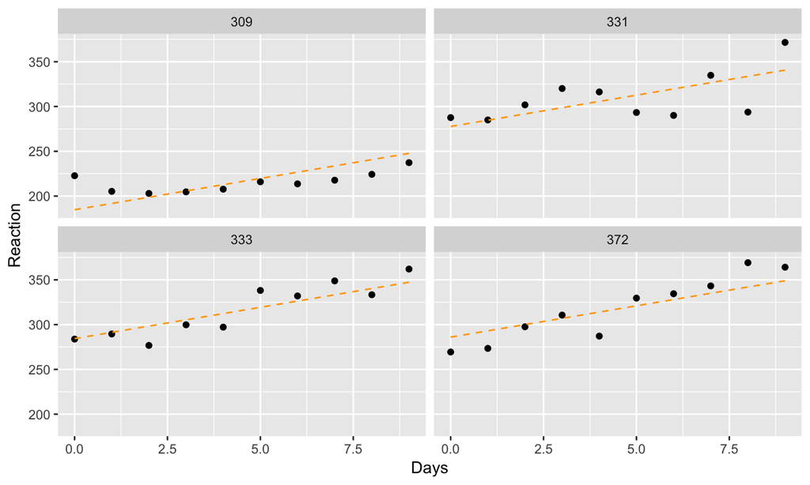

## Densities

- Y|U and U are multivariate normal variables
- Using sum of squares \(\rho^2(\theta, \beta, u) := \big\| y_\text{obs} - \mu_{Y | U=u} \big\|^2\) \[ \begin{aligned} f_{Y|U}({y_\text{obs}}| u) &= \frac{1}{(2\pi \sigma^2)^{n/2}} \cdot \exp \frac{-\rho^2(\theta, \beta, u)}{2\sigma^2}\\ f_U (u) &= \frac{1}{(2\pi\sigma^2)^{q/2}} \cdot \exp \frac{- \|u\|^2}{2\sigma^2} \\ \end{aligned} \]

## Joint density

\[ \begin{aligned} f_{Y,U}({y_\text{obs}}, u) &= f_{Y|U}({y_\text{obs}}| u) \qquad \cdot \qquad f_U (u) \\ & = \frac{1}{(2\pi \sigma^2)^{n/2}} \exp \frac{-\rho^2(\theta, \beta, u)}{2\sigma^2} \; \cdot \; \frac{1}{(2\pi\sigma^2)^{q/2}} \exp \frac{- \|u\|^2}{2\sigma^2} \\ & = \frac{1}{(2\pi \sigma^2)^{(n+q)/2}} \cdot \exp \frac{-\rho^2(\theta, \beta, u) - \|u\|^2 }{2\sigma^2}\\ & = \frac{1}{(2\pi \sigma^2)^{(n+q)/2}} \cdot \exp \frac{-r^2(\theta, \beta, u) }{2\sigma^2} \end{aligned} \]

- **penalized sum-of-squares** \(r^2(\theta, \beta, u) := \rho^2(\theta, \beta, u) + \|u\|^2\)

## Likelihood

\[ \begin{aligned} L(\theta, \beta, \sigma^2 | {y_\text{obs}}) &= f_Y({y_\text{obs}}) \\ &= \int f_{Y,U}({y_\text{obs}}, u) du \\ &= \int f_{Y|U}({y_\text{obs}}| u) \cdot f_U(u) du\\ &= \frac{1}{(2\pi \sigma^2)^{(n+q)/2}} \cdot \int \exp \frac{-r^2(\theta, \beta, u)}{2\sigma^2} du \end{aligned} \]

## Likelihood for random intercept model

- Contribution for subject \(i\)

\[ \begin{aligned} L_i(\theta, \beta, \sigma^2 | y_i) &= f_Y(y_i) = \int f_{Y,U}(y_i, u_i) \, du_i \\ &= \int f_{Y|U}(y_i | u_i) \cdot f_U(u_i) \, du_i\\ &= \int ϕ_{X_i β + \frac{σ_b}{σ}u_i, σ^2}(y_i)\cdot ϕ_{0, σ^2} (u_i) \, du_i\\ &= \int ϕ_{X_i β + b_i, σ^2}(y_i) \cdot ϕ_{0, σ_b^2} (b_i) \, db_i\\ \end{aligned} \]

- Together **not** a product of likelihood contribution of individual observations

## Efficient Estimation of Linear Mixed Models

## Pseudo-data approach

- amend the observed data \(y_\text{obs}\) with an "observed" \(u_\text{obs}=0\) for the (unobservable) spherical random-effects variable \(u\)
- PLS-problem becomes a standard least square problem in the amended space

\[ \begin{aligned} r^2(\theta, \beta, u) &= \Big\| \begin{bmatrix} {y_\text{obs}}- \mu_{Y | U=u} \\ -u \end{bmatrix} \Big\|^2 \\ &= \Big\| \underbrace{\begin{bmatrix} {y_\text{obs}}\\ 0\end{bmatrix}}_{ =: \tilde y} - \underbrace{\begin{bmatrix} Z \Lambda_\theta & X \\ I_q & 0\end{bmatrix}}_{ =: \tilde X_θ} \begin{bmatrix} u \\ \beta \end{bmatrix} \Big\|^2 \end{aligned} \]

- Find optimal parameters \(\hat \mu_{U|Y=y_\text{obs}}, \hat \beta_\theta\) (via normal equation) as function of θ
- Define \(\mathbf{r^2(\theta)} := r^2(\theta, \hat \beta_\theta, \hat \mu_{U|Y=y_\text{obs}})\)

## Maximum Likelihood Estimation

- Parameterized by θ only (β and σ profiled out)

\[ \begin{aligned} \log L (\theta | y_{\text{obs}}) &= \log |L_\theta |{^{-1}}- \frac{n}{2} \cdot \big[ 1 + \log \frac{2 \pi \cdot r^2(\theta)}{n} \big]\\[.5ex] &\; (L_θ \text{ is a matrix derived from } \tilde X_θ) \end{aligned} \]

- Use general optimizer to maximize \(θ \mapsto L(θ)\)
- Repeated evaluation of PLS-algorithm

## Mixed models with Censoring

## Example: sleepstudy

- Subset of `sleepstudy`-data with left- and right-censoring

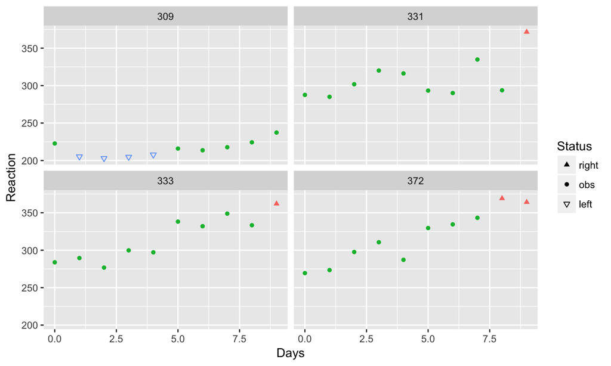

## Likelihood w/ left censoring

- Contribution for subject \(i\)

\[ \begin{aligned} L_i(\theta, \beta, \sigma^2 | y_i) &= f_Y(y_i) \\ &= \int f_{Y,U}(y_i, u_i) du_i \\ &= \int f_{Y|U}(y_i | u_i) \cdot f_U(u_i) du_i \\ &= \int \bigl[ \prod_{t∈D} ϕ_{x_{it}{^\intercal}β + b_i, σ^2}(y_{it}) \prod_{k∈L} Φ_{x_{ik}{^\intercal}β + b_i, σ^2}(y_{ik}) \bigr] \cdot ϕ_{0, σ_b^2}(b_i) db_i\\ \end{aligned} \]

## Gauß-Hermite quadrature

- Evaluate an improper integral as weighted average of order o
- Fewer function evaluations than standard numerical integration \[ \int_{-\infty}^\infty \exp(-x^2) \;f(x) \, dx \approx \sum_{i=1}^o w_i \cdot f(x_i) \]

```
## Unit: seconds
##                                     expr       min        lq      mean
##     optim(par = paramS, fn = myDevFun_f) 22.032155 22.552721 22.593906
##  optim(par = paramS, fn = myDevFun_gh_f)  1.028293  1.043191  1.087595
##    median        uq       max neval cld
##  22.58022 22.592683 23.211745     5   b
##   1.05152  1.075112  1.239857     5  a
```

## Implementation in `lme4cens`

- Random intercept model
- Re-use modules from `lme4`

```r
lFormula(Surv(Reaction, time2 = Reaction, event = event2, type = "interval") ~
           Days + (1|Subject), data = sleepstudy2, REML = FALSE) %>%
  do.call(mkLmerCensDevfun_rInt_R, .) ->
  myDevFun

## optimize deviance function
paramS <- c(int=260, slope=5, logS_betw=3, logS=2)
parEstim <- optim(fn = myDevFun, par = paramS)

c(parEstim$par, logLik = -parEstim$value)
```

```
##         int       slope   logS_betw        logS      logLik
##  240.815167    8.184225    3.449740    2.875997 -151.827432
```

## Outlook

- Validate results:
  - simulation studies
  - package `censReg` implements random-intercept censored regression in R
- Implement also restricted maximum likelihood (REML)
- Implement non-linear mixed models with censoring
- Tap deeper into `lme4`-structures
- Allow for more complex random-effect structures
  - Other fitting methods: *maximum simulated likelihood*

~ Fine ~

## Backup slides

## Likelihood Model for Left-Censoring

- Censoring \(C_l\) \[ \begin{aligned} P(t ≤ T ≤ t + h, δ = 0) &= P(t ≤ C_l ≤ t + h, C_l ≥ X)\\ &\approx P(t ≤ C_l ≤ t + h, t ≥ X)\\ &= P(t ≤ C_l ≤ t + h) \cdot P(X ≤ t)\\ &= g(ξ) h \cdot (1-S(t)) \qquad \text{ a ξ ∈ [t, t+h)}\\[1ex] \end{aligned} \]
- Observed response \(X\) \[ \begin{aligned} P(t ≤ T ≤ t + h, δ = 1) &= P(t ≤ X ≤ t + h, C_l ≤ X)\\ &\approx P(t ≤ X ≤ t + h, C_l ≤ t)\\ &= P(t ≤ X ≤ t + h) \cdot P(C_l ≤ t)\\ &= f(ξ) h \cdot (1-H(t)) \qquad \text{ a ξ ∈ [t, t+h)} \end{aligned} \]